# Results - Wells by state and wildfire-year (primary analysis)

# 1 Description

These analyses are for the assessments of the number of wells in all wildfire burn areas by state and year (1984-2020). These are oil and gas wells with any operation date before the year of the wildfire and wells with missing operation dates, which we presume to have been drilled before the study period in an era of poor record-keeping. In a sensitivity analysis, we omit wells without data on operation dates.

# 2 Aggregated results for all states

## 2.1 Wells in wildfire burn areas

### 2.1.1 Summary of wells in wildfire burn areas by year

```
   Min. 1st Qu.  Median    Mean 3rd Qu.    Max.
   68.0   438.0   778.5  2857.8  3828.2 18047.0
[1] 4011.921
```

### 2.1.2 Total wells burned by decade

- 1984-1989: **4439**
- 1990-1999: **9536**
- 2000-2009: **3.7925^{4}**
- 2010-2019: **5.0982^{4}**

### 2.1.4 Table. Wells in wildfire burn areas by state

| state | n | n_wells_buffer_1km |
| --- | --- | --- |
| AK | 5 | 11 |
| AR | 236 | 962 |
| AZ | 0 | 0 |
| CA | 17143 | 68134 |
| CO | 207 | 1573 |
| KS | 4869 | 12001 |
| LA | 682 | 3542 |
| MO | 0 | 0 |
| MT | 268 | 936 |
| ND | 227 | 1560 |

[output cut: 9 more lines]

### 2.1.5 Table. Wells in wildfire burn areas by year

| year | n | n_wells_buffer_1km |
| --- | --- | --- |
| 1984 | 581 | 2697 |
| 1985 | 597 | 1110 |
| 1986 | 439 | 1650 |
| 1987 | 68 | 830 |
| 1988 | 2457 | 5089 |
| 1989 | 297 | 1464 |
| 1990 | 219 | 1364 |
| 1991 | 482 | 1255 |
| 1992 | 117 | 1084 |
| 1993 | 1135 | 4495 |

[output cut: 26 more lines]

### 2.1.6 Plot. Wells in wildfire burn areas by year

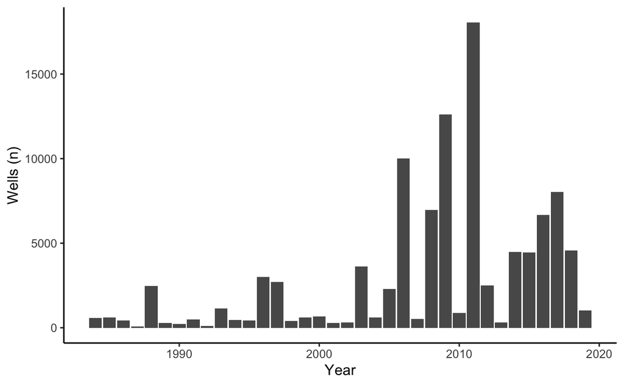

### 2.1.7 Plot. Wells in wildfire burn areas by year with best fit line

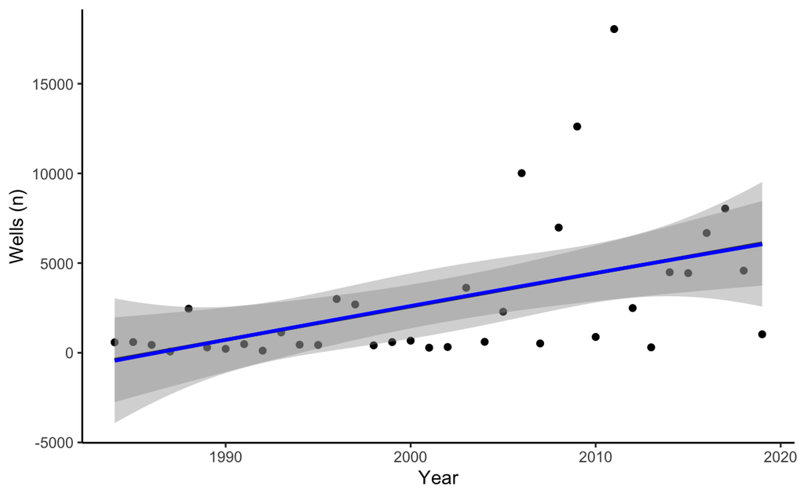

### 2.1.8 Model. Wells in burn area ~ year

```
Call:
glm(formula = n_wells ~ year, family = "poisson", data = wells_wildfire_state_year)

Coefficients:
              Estimate Std. Error z value Pr(>|z|)
(Intercept) -1.390e+02  7.021e-01  -198.0   <2e-16 ***
year         7.184e-02  3.496e-04   205.5   <2e-16 ***
---
Signif. codes:  0 ‘***’ 0.001 ‘**’ 0.01 ‘*’ 0.05 ‘.’ 0.1 ‘ ’ 1

(Dispersion parameter for poisson family taken to be 1)

    Null deviance: 544654  on 683  degrees of freedom
Residual deviance: 495497  on 682  degrees of freedom
AIC: 497117

Number of Fisher Scoring iterations: 8
```

### 2.1.9 Model. Wells in burn area ~ year * state

```
Call:
glm(formula = n_wells ~ year + factor(state), family = "poisson",
    data = wells_wildfire_state_year)

Coefficients:
                  Estimate Std. Error  z value Pr(>|z|)
(Intercept)     -1.460e+02  8.324e-01 -175.424  < 2e-16 ***
year             7.184e-02  3.496e-04  205.517  < 2e-16 ***
factor(state)AR  3.854e+00  4.519e-01    8.529  < 2e-16 ***
factor(state)AZ -1.124e+01  7.485e+01   -0.150    0.881
factor(state)CA  8.140e+00  4.473e-01   18.199  < 2e-16 ***
factor(state)CO  3.723e+00  4.526e-01    8.227  < 2e-16 ***
factor(state)KS  6.881e+00  4.474e-01   15.379  < 2e-16 ***
factor(state)LA  4.916e+00  4.488e-01   10.952  < 2e-16 ***
factor(state)MO -1.124e+01  7.485e+01   -0.150    0.881
factor(state)MT  3.982e+00  4.514e-01    8.821  < 2e-16 ***
factor(state)ND  3.816e+00  4.521e-01    8.439  < 2e-16 ***
factor(state)NE -5.108e-01  7.303e-01   -0.699    0.484
factor(state)NM  6.808e+00  4.475e-01   15.215  < 2e-16 ***
factor(state)NV -1.124e+01  7.485e+01   -0.150    0.881
factor(state)OK  8.971e+00  4.472e-01   20.058  < 2e-16 ***
factor(state)OR -1.124e+01  7.485e+01   -0.150    0.881
factor(state)SD  2.912e+00  4.592e-01    6.342 2.27e-10 ***
factor(state)TX  8.777e+00  4.472e-01   19.625  < 2e-16 ***
factor(state)UT  3.622e+00  4.532e-01    7.992 1.33e-15 ***
factor(state)WY  6.277e+00  4.476e-01   14.022  < 2e-16 ***
---
Signif. codes:  0 ‘***’ 0.001 ‘**’ 0.01 ‘*’ 0.05 ‘.’ 0.1 ‘ ’ 1

(Dispersion parameter for poisson family taken to be 1)

    Null deviance: 544654  on 683  degrees of freedom
Residual deviance: 201081  on 664  degrees of freedom
AIC: 202737

Number of Fisher Scoring iterations: 11
```

## 2.2 Wells within 1 km of wildfire burn areas

### 2.2.1 Plot. Wells within 1km of wildfire burn areas by year

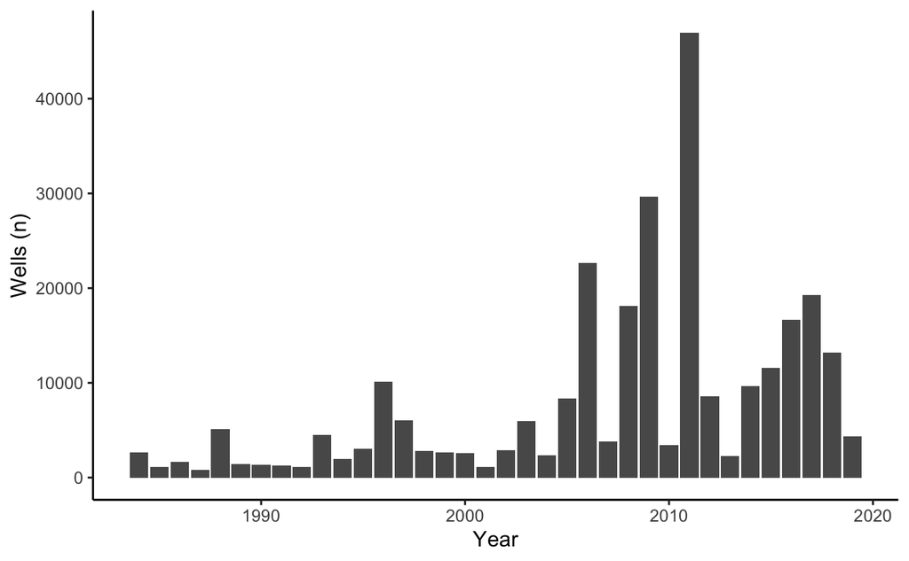

### 2.2.2 Plot. Wells within 1 km of wildfire burn areas by year with best fit line

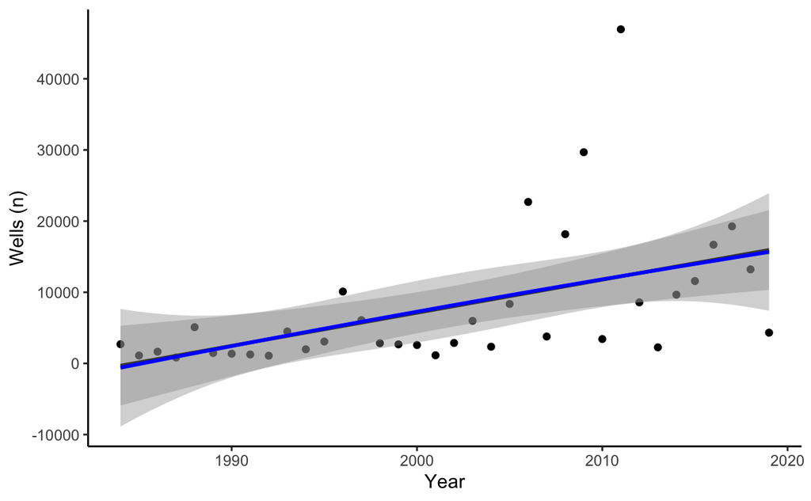

### 2.2.3 Model. Wells within 1km of burn area ~ year * state

```
Call:
glm(formula = n_wells_buffer_1km ~ year + factor(state), family = "poisson",
    data = wells_wildfire_state_year)

Coefficients:
                  Estimate Std. Error  z value Pr(>|z|)
(Intercept)     -1.308e+02  5.115e-01 -255.659  < 2e-16 ***
year             6.464e-02  2.058e-04  314.103  < 2e-16 ***
factor(state)AR  4.471e+00  3.032e-01   14.745  < 2e-16 ***
factor(state)AZ -1.104e+01  4.554e+01   -0.242 0.808545
factor(state)CA  8.731e+00  3.015e-01   28.956  < 2e-16 ***
factor(state)CO  4.963e+00  3.026e-01   16.403  < 2e-16 ***
factor(state)KS  6.995e+00  3.016e-01   23.189  < 2e-16 ***
factor(state)LA  5.775e+00  3.020e-01   19.122  < 2e-16 ***
factor(state)MO -1.104e+01  4.554e+01   -0.242 0.808545
factor(state)MT  4.444e+00  3.033e-01   14.652  < 2e-16 ***
factor(state)ND  4.955e+00  3.026e-01   16.375  < 2e-16 ***
factor(state)NE  1.240e+00  3.424e-01    3.621 0.000294 ***
factor(state)NM  7.229e+00  3.016e-01   23.967  < 2e-16 ***
factor(state)NV -1.012e+00  5.839e-01   -1.733 0.083173 .
factor(state)OK  8.996e+00  3.015e-01   29.835  < 2e-16 ***
factor(state)OR -1.104e+01  4.554e+01   -0.242 0.808545
factor(state)SD  3.269e+00  3.072e-01   10.640  < 2e-16 ***
factor(state)TX  8.860e+00  3.015e-01   29.384  < 2e-16 ***
factor(state)UT  4.215e+00  3.037e-01   13.879  < 2e-16 ***
factor(state)WY  6.819e+00  3.017e-01   22.603  < 2e-16 ***
---
Signif. codes:  0 ‘***’ 0.001 ‘**’ 0.01 ‘*’ 0.05 ‘.’ 0.1 ‘ ’ 1

(Dispersion parameter for poisson family taken to be 1)

    Null deviance: 1253746  on 683  degrees of freedom
Residual deviance:  413448  on 664  degrees of freedom
AIC: 415949

Number of Fisher Scoring iterations: 10
```

In models adjusted for state, the number of wells within 1km of wildfire burn areas (including wells within and just outside of the burn areas) increased throughout the study period, 1984-2020 (p < 0.001).

# 3 Stratified by state

## 3.1 Wells in wildfire burn areas

### 3.1.1 Table. Wells in wildfire burn areas by state

| state | n_wells_by_state | n_wells_buffer_1km_by_state |
| --- | --- | --- |
| OK | 39352 | 88783 |
| TX | 32426 | 77498 |
| CA | 17143 | 68134 |
| KS | 4869 | 12001 |
| NM | 4525 | 15168 |
| WY | 2660 | 10064 |
| LA | 682 | 3542 |
| MT | 268 | 936 |
| AR | 236 | 962 |
| ND | 227 | 1560 |

[output cut: 9 more lines]

### 3.1.2 Plot. Wells in wildfire burn areas by state

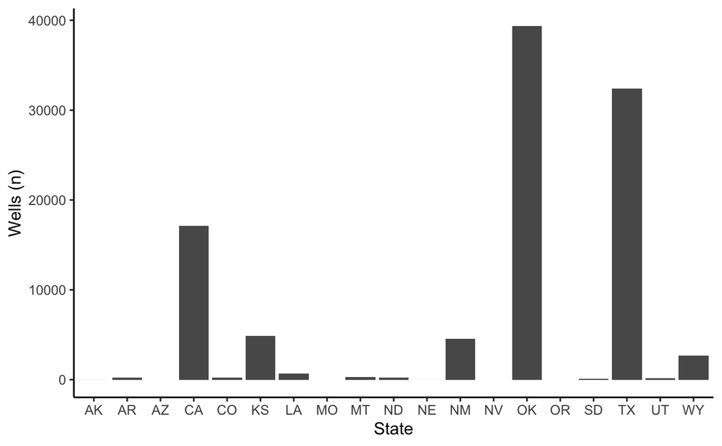

### 3.1.3 Table. Wells in wildfire burn areas by state and year

| state | year | n | n_wells_buffer_1km |
| --- | --- | --- | --- |
| AK | 1984 | 0 | 0 |
| AK | 1985 | 0 | 0 |
| AK | 1986 | 0 | 0 |
| AK | 1987 | 0 | 0 |
| AK | 1988 | 0 | 0 |
| AK | 1989 | 1 | 1 |
| AK | 1990 | 0 | 0 |
| AK | 1991 | 0 | 0 |
| AK | 1992 | 0 | 0 |
| AK | 1993 | 0 | 0 |

[output cut: 674 more lines]

### 3.1.4 Plot. Wells in wildfire burn areas by state and year

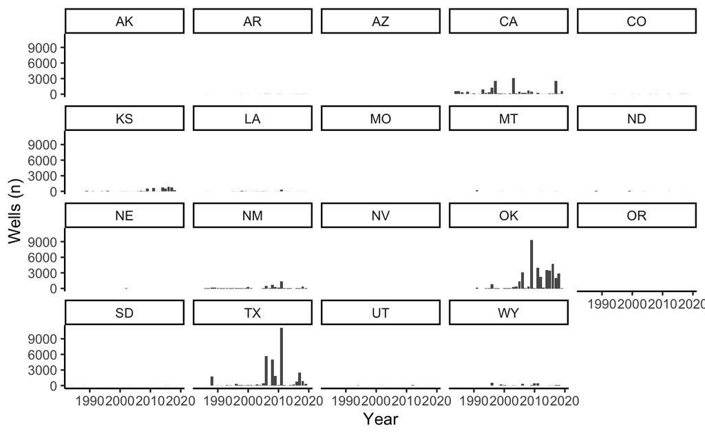

### 3.1.5 Plot. Wells in wildfire burn areas by year with best fit line

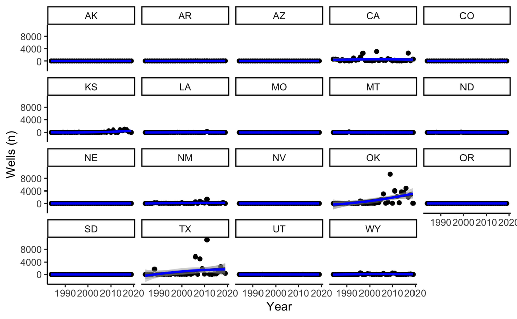

## 3.2 Investigating time trends by state

### 3.2.1 Model. Wells in burn area ~ year * state (CA)

```
Call:
glm(formula = n_wells ~ year, family = "poisson", data = subset(wells_wildfire_state_year,
    state == "CA"))

Coefficients:
              Estimate Std. Error z value Pr(>|z|)
(Intercept) -2.1736036  1.4727041  -1.476     0.14
year         0.0041661  0.0007356   5.663 1.48e-08 ***
---
Signif. codes:  0 ‘***’ 0.001 ‘**’ 0.01 ‘*’ 0.05 ‘.’ 0.1 ‘ ’ 1

(Dispersion parameter for poisson family taken to be 1)

    Null deviance: 27742  on 35  degrees of freedom
Residual deviance: 27710  on 34  degrees of freedom
AIC: 27960

Number of Fisher Scoring iterations: 6
```

### 3.2.2 Model. Wells in burn area ~ year * state (OK)

```
Call:
glm(formula = n_wells ~ year, family = "poisson", data = subset(wells_wildfire_state_year,
    state == "OK"))

Coefficients:
              Estimate Std. Error z value Pr(>|z|)
(Intercept) -2.268e+02  1.387e+00  -163.5   <2e-16 ***
year         1.165e-01  6.896e-04   169.0   <2e-16 ***
---
Signif. codes:  0 ‘***’ 0.001 ‘**’ 0.01 ‘*’ 0.05 ‘.’ 0.1 ‘ ’ 1

(Dispersion parameter for poisson family taken to be 1)

    Null deviance: 92441  on 35  degrees of freedom
Residual deviance: 52097  on 34  degrees of freedom
AIC: 52297

Number of Fisher Scoring iterations: 7
```

Increasing number of wells in burn areas in Oklahoma (p < 0.01).

### 3.2.3 Model. Wells in burn area ~ year * state (TX)

```
Call:
glm(formula = n_wells ~ year, family = "poisson", data = subset(wells_wildfire_state_year,
    state == "TX"))

Coefficients:
              Estimate Std. Error z value Pr(>|z|)
(Intercept) -1.399e+02  1.257e+00  -111.3   <2e-16 ***
year         7.315e-02  6.258e-04   116.9   <2e-16 ***
---
Signif. codes:  0 ‘***’ 0.001 ‘**’ 0.01 ‘*’ 0.05 ‘.’ 0.1 ‘ ’ 1

(Dispersion parameter for poisson family taken to be 1)

    Null deviance: 94989  on 35  degrees of freedom
Residual deviance: 79009  on 34  degrees of freedom
AIC: 79243

Number of Fisher Scoring iterations: 7
```

Trend of increasing number of wells in burn areas in Texas, statistically significant.

### 3.2.4 Model. Wells in burn area ~ year * state (KS)

```
Call:
glm(formula = n_wells ~ year, family = "poisson", data = subset(wells_wildfire_state_year,
    state == "KS"))

Coefficients:
              Estimate Std. Error z value Pr(>|z|)
(Intercept) -2.671e+02  4.330e+00  -61.70   <2e-16 ***
year         1.355e-01  2.151e-03   62.98   <2e-16 ***
---
Signif. codes:  0 ‘***’ 0.001 ‘**’ 0.01 ‘*’ 0.05 ‘.’ 0.1 ‘ ’ 1

(Dispersion parameter for poisson family taken to be 1)

    Null deviance: 11847.2  on 35  degrees of freedom
Residual deviance:  5722.4  on 34  degrees of freedom
AIC: 5896.8

Number of Fisher Scoring iterations: 6
```

### 3.2.5 Model. Wells in burn area ~ year * state (NM)

```
Call:
glm(formula = n_wells ~ year, family = "poisson", data = subset(wells_wildfire_state_year,
    state == "NM"))

Coefficients:
              Estimate Std. Error z value Pr(>|z|)
(Intercept) -86.533588   3.063318  -28.25   <2e-16 ***
year          0.045595   0.001527   29.86   <2e-16 ***
---
Signif. codes:  0 ‘***’ 0.001 ‘**’ 0.01 ‘*’ 0.05 ‘.’ 0.1 ‘ ’ 1

(Dispersion parameter for poisson family taken to be 1)

    Null deviance: 10985  on 35  degrees of freedom
Residual deviance: 10034  on 34  degrees of freedom
AIC: 10197

Number of Fisher Scoring iterations: 6
```

Positive time trend in NM

### 3.2.6 Model. Wells in burn area ~ year * state (WY)

```
Call:
glm(formula = n_wells ~ year, family = "poisson", data = subset(wells_wildfire_state_year,
    state == "WY"))

Coefficients:
              Estimate Std. Error z value Pr(>|z|)
(Intercept) -76.547365   3.940295  -19.43   <2e-16 ***
year          0.040352   0.001965   20.54   <2e-16 ***
---
Signif. codes:  0 ‘***’ 0.001 ‘**’ 0.01 ‘*’ 0.05 ‘.’ 0.1 ‘ ’ 1

(Dispersion parameter for poisson family taken to be 1)

    Null deviance: 6805.4  on 35  degrees of freedom
Residual deviance: 6361.3  on 34  degrees of freedom
AIC: 6485.5

Number of Fisher Scoring iterations: 7
```

Statistically significant positive trend in WY